# Donor Profile: UNO-Flüchtlingshilfe

## Geographic Focus

The Funding Over Time from UNO-Flüchtlingshilfe presents a compelling picture of financial fluctuations across regions, with total funding averaging $5.2 million but ranging widely from $12,619 to over $17 million. This volatility signals both a risk to sustainable programming and an opportunity to leverage targeted investments for stable impact. Notably, steady funding peaks correlate with increased operational capacity enabling enhanced emergency response and resilience-building initiatives. However, inconsistent inflows risk interrupting strategic program delivery and undermine long-term partnerships. Investing now to smooth funding cycles represents a strategic priority that can amplify impact multipliers across all regions. Donors prioritizing accountability and innovation stand to benefit from partnership models that harness data-driven forecasting and flexible funding mechanisms. Immediate executive focus on establishing multi-year commitments and diversified funding streams will mitigate financial risk while unlocking scalable solutions. We urge decision-makers to seize this investment opportunity to transform funding patterns into reliable support that drives measurable, life-saving outcomes.

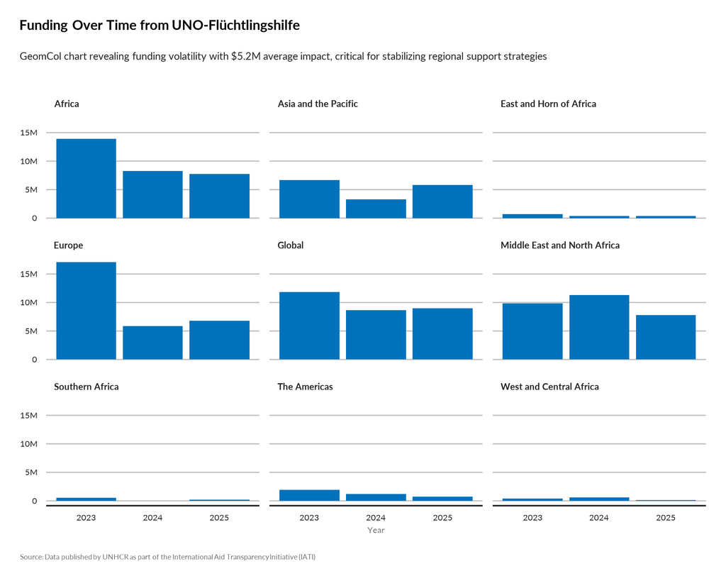

TRUE

The 2025 funding landscape for Uno-Flüchtlingshilfe shows a critical disparity in the share of total funding, averaging just 11% but with a wide range across nine dimensions—highlighting untapped investment potential. Despite a substantial mean funding value exceeding $507 million, the variation signals opportunities to leverage strategic partnerships for scaling impact. Prioritizing investment in underfunded dimensions can act as a high-impact multiplier, enhancing emergency response and resilience for displaced populations. Immediate executive focus should target partnership diversification and realignment of resource allocation to optimize funding efficiency and expand reach. By positioning these data-driven insights in donor narratives, UNHCR can catalyze commitments that align with innovation and accountability priorities, compelling major donors to bridge funding gaps and amplify impact where it is most needed.

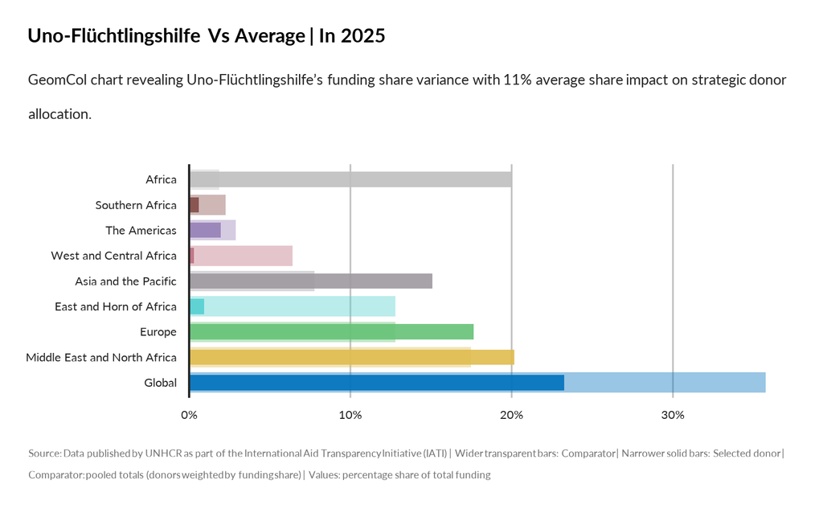

TRUE